# Reproducible Research Project2

Yan

3/15/2018

# The most severe weather events that affect public health and economic in the United States

## Synopsis

This project is about the health and economic problems caused by storms. The downloaded data needs to be cleaned following the instruction of the documentation. Group the dataset according to different event type and find out the type that has the largest damage to public health including fatalities and injuries, as well as economic impact including properties and crops.

### Introduction

Storms and other severe weather events can cause both public health and economic problems for communities and municipalities. Many severe events can result in fatalities, injuries, and property damage, and preventing such outcomes to the extent possible is a key concern.

This project involves exploring the U.S. National Oceanic and Atmospheric Administration’s (NOAA) storm database. This database tracks characteristics of major storms and weather events in the United States, including when and where they occur, as well as estimates of any fatalities, injuries, and property damage.

### Data

The data for this assignment come in the form of a comma-separated-value compressed file via the bzip2 algorithm to reduce its size. You can download the file from the course web site:  
* [Storm Data](https://d396qusza40orc.cloudfront.net/repdata%2Fdata%2FStormData.csv.bz2) [47Mb]

There is also some documentation of the database available. Here you will find how some of the variables are constructed/defined.  
* National Weather Service [Storm Data Documentation](https://d396qusza40orc.cloudfront.net/repdata%2Fpeer2_doc%2Fpd01016005curr.pdf)  
* National Climatic Data Center Storm Events [FAQ](https://d396qusza40orc.cloudfront.net/repdata%2Fpeer2_doc%2FNCDC%20Storm%20Events-FAQ%20Page.pdf)

The events in the database start in the year 1950 and end in November 2011. In the earlier years of the database there are generally fewer events recorded, most likely due to a lack of good records. More recent years should be considered more complete.

### Questions

The basic goal of this assignment is to explore the NOAA Storm Database and answer some basic questions about severe weather events. You must use the database to answer the questions below and show the code for your entire analysis. Your analysis can consist of tables, figures, or other summaries. You may use any R package you want to support your analysis.

**Your data analysis must address the following questions:**

1. Across the United States, which types of events (as indicated in the *EVTYPE* variable) are most harmful with respect to population health?
2. Across the United States, which types of events have the greatest economic consequences?

Consider writing your report as if it were to be read by a government or municipal manager who might be responsible for preparing for severe weather events and will need to prioritize resources for different types of events. However, there is no need to make any specific recommendations in your report.

#### Requirement(tools)

- Rstudio
- knitr

```r
library(dplyr)
```

```r
library(ggplot2)
```

## Data Processing

### set directory and download data from web

```r
setwd("~/GoogleDrive/workshop/Data Science Specialization/05_Reproducible Research/project2/")
fname<-"stormdata.csv.bz2"
furl<-"https://d396qusza40orc.cloudfront.net/repdata%2Fdata%2FStormData.csv.bz2"
fname2<-"stormdatadoc.pdf"
furl2<-"https://d396qusza40orc.cloudfront.net/repdata%2Fpeer2_doc%2Fpd01016005curr.pdf"
fname3<-"stormdatafaq.pdf"
furl3<-"https://d396qusza40orc.cloudfront.net/repdata%2Fpeer2_doc%2FNCDC%20Storm%20Events-FAQ%20Page.pdf"
if(!file.exists(fname)){download.file(furl,fname)}
if(!file.exists(fname2)){download.file(furl2,fname2)}
if(!file.exists(fname3)){download.file(furl3,fname3)}
list.files(recursive = TRUE)
```

```
## [1] "Course Project 2.pdf" "project2.html"        "project2.Rmd"
## [4] "stormdata.csv"        "stormdata.csv.bz2"    "stormdatadoc.pdf"
## [7] "stormdatafaq.pdf"
```

### read data and check data structure

```r
storm<-read.csv(fname,na.strings = "")
str(storm)
```

```
## 'data.frame':    902297 obs. of  37 variables:
##  $ STATE__   : num  1 1 1 1 1 1 1 1 1 1 ...
##  $ BGN_DATE  : Factor w/ 16335 levels "1/1/1966 0:00:00",..: 6523 6523 4242 11116 2224 2224 2260 383 3980 3980 ...
##  $ BGN_TIME  : Factor w/ 3608 levels "00:00:00 AM",..: 272 287 2705 1683 2584 3186 242 1683 3186 3186 ...
##  $ TIME_ZONE : Factor w/ 22 levels "ADT","AKS","AST",..: 7 7 7 7 7 7 7 7 7 7 ...
##  $ COUNTY    : num  97 3 57 89 43 77 9 123 125 57 ...
##  $ COUNTYNAME: Factor w/ 29600 levels "5NM E OF MACKINAC BRIDGE TO PRESQUE ISLE LT MI",..: 13512 1872 4597 10591 4371 10093 1972 23872 24417 4597 ...
##  $ STATE     : Factor w/ 72 levels "AK","AL","AM",..: 2 2 2 2 2 2 2 2 2 2 ...
##  $ EVTYPE    : Factor w/ 985 levels "   HIGH SURF ADVISORY",..: 834 834 834 834 834 834 834 834 834 834 ...
##  $ BGN_RANGE : num  0 0 0 0 0 0 0 0 0 0 ...
##  $ BGN_AZI   : Factor w/ 34 levels "  N"," NW","E",..: NA NA NA NA NA NA NA NA NA NA ...
##  $ BGN_LOCATI: Factor w/ 54428 levels " Christiansburg",..: NA NA NA NA NA NA NA NA NA NA ...
##  $ END_DATE  : Factor w/ 6662 levels "1/1/1993 0:00:00",..: NA NA NA NA NA NA NA NA NA NA ...
##  $ END_TIME  : Factor w/ 3646 levels " 0900CST"," 200CST",..: NA NA NA NA NA NA NA NA NA NA ...
##  $ COUNTY_END: num  0 0 0 0 0 0 0 0 0 0 ...
```

[output cut: 23 more lines]

### select effective rows and columns

Some lines in between is not correct record, remove those based on the “STATE” column  
compare with state.abb data in R

```r
storm<-tbl_df(storm)
sstorm<- storm %>%
  filter(STATE %in% state.abb) %>%
  select(EVTYPE,FATALITIES,INJURIES,PROPDMG,PROPDMGEXP,CROPDMG,CROPDMGEXP) %>%
  print
```

```
## # A tibble: 883,186 x 7
##    EVTYPE  FATALITIES INJURIES PROPDMG PROPDMGEXP CROPDMG CROPDMGEXP
##    <fctr>       <dbl>    <dbl>   <dbl> <fctr>       <dbl> <fctr>
##  1 TORNADO       0       15.0    25.0  K                0 <NA>
##  2 TORNADO       0        0       2.50 K                0 <NA>
##  3 TORNADO       0        2.00   25.0  K                0 <NA>
##  4 TORNADO       0        2.00    2.50 K                0 <NA>
##  5 TORNADO       0        2.00    2.50 K                0 <NA>
##  6 TORNADO       0        6.00    2.50 K                0 <NA>
##  7 TORNADO       0        1.00    2.50 K                0 <NA>
##  8 TORNADO       0        0       2.50 K                0 <NA>
##  9 TORNADO       1.00    14.0    25.0  K                0 <NA>
## 10 TORNADO       0        0      25.0  K                0 <NA>
## # ... with 883,176 more rows
```

```r
summary(sstorm)
```

```
##                EVTYPE         FATALITIES          INJURIES
##  HAIL             :288614   Min.   :  0.0000   Min.   :   0.0000
##  TSTM WIND        :219807   1st Qu.:  0.0000   1st Qu.:   0.0000
##  THUNDERSTORM WIND: 82477   Median :  0.0000   Median :   0.0000
##  TORNADO          : 60635   Mean   :  0.0168   Mean   :   0.1579
##  FLASH FLOOD      : 53274   3rd Qu.:  0.0000   3rd Qu.:   0.0000
##  FLOOD            : 24951   Max.   :583.0000   Max.   :1700.0000
##  (Other)          :153428
##     PROPDMG          PROPDMGEXP        CROPDMG          CROPDMGEXP
##  Min.   :   0.00   K      :415375   Min.   :  0.000   K      :273262
##  1st Qu.:   0.00   M      : 11254   1st Qu.:  0.000   M      :  1969
##  Median :   0.00   0      :   216   Median :  0.000   k      :    21
##  Mean   :  12.25   B      :    39   Mean   :  1.549   0      :    19
##  3rd Qu.:   1.00   5      :    28   3rd Qu.:  0.000   B      :     9
##  Max.   :5000.00   (Other):    84   Max.   :990.000   (Other):     9
##                    NA's   :456190                     NA's   :607897
```

### clean data

#### change string to all upper case

```r
sstorm$EVTYPE<-toupper(sstorm$EVTYPE)
sstorm$PROPDMGEXP<-toupper(sstorm$PROPDMGEXP)
sstorm$CROPDMGEXP<-toupper(sstorm$CROPDMGEXP)
summary(sstorm)
```

```
##     EVTYPE            FATALITIES          INJURIES
##  Length:883186      Min.   :  0.0000   Min.   :   0.0000
##  Class :character   1st Qu.:  0.0000   1st Qu.:   0.0000
##  Mode  :character   Median :  0.0000   Median :   0.0000
##                     Mean   :  0.0168   Mean   :   0.1579
##                     3rd Qu.:  0.0000   3rd Qu.:   0.0000
##                     Max.   :583.0000   Max.   :1700.0000
##     PROPDMG         PROPDMGEXP           CROPDMG         CROPDMGEXP
##  Min.   :   0.00   Length:883186      Min.   :  0.000   Length:883186
##  1st Qu.:   0.00   Class :character   1st Qu.:  0.000   Class :character
##  Median :   0.00   Mode  :character   Median :  0.000   Mode  :character
##  Mean   :  12.25                      Mean   :  1.549
##  3rd Qu.:   1.00                      3rd Qu.:  0.000
##  Max.   :5000.00                      Max.   :990.000
```

#### calculate exponential , build function

Note: *if* function is not vectorized, use *ifelse* instead

```r
exptovalue <- function(x) {
  ifelse(x=="B",1e9, ifelse(x=="M",1e6, ifelse(x=="K",1e3,1)))
}
nazero <- function(x) {
  ifelse(is.na(x),0,x)
}
```

```r
sstorm <- sstorm %>%
  mutate(proploss=PROPDMG*exptovalue(PROPDMGEXP)) %>%
  mutate(croploss=CROPDMG*exptovalue(CROPDMGEXP)) %>%
  mutate(totalloss=nazero(proploss)+nazero(croploss)) %>%
  select(-PROPDMG,-PROPDMGEXP,-CROPDMG,-CROPDMGEXP) %>%
  print
```

```
## # A tibble: 883,186 x 6
##    EVTYPE  FATALITIES INJURIES proploss croploss totalloss
##    <chr>        <dbl>    <dbl>    <dbl>    <dbl>     <dbl>
##  1 TORNADO       0       15.0     25000       NA     25000
##  2 TORNADO       0        0        2500       NA      2500
##  3 TORNADO       0        2.00    25000       NA     25000
##  4 TORNADO       0        2.00     2500       NA      2500
##  5 TORNADO       0        2.00     2500       NA      2500
##  6 TORNADO       0        6.00     2500       NA      2500
##  7 TORNADO       0        1.00     2500       NA      2500
##  8 TORNADO       0        0        2500       NA      2500
##  9 TORNADO       1.00    14.0     25000       NA     25000
## 10 TORNADO       0        0       25000       NA     25000
## # ... with 883,176 more rows
```

Calculate the damage value for property and crop respectively, then add two items together.  
Remove the original damage data columns.

#### modify event type

```r
length(unique(sstorm$EVTYPE))
```

```
## [1] 867
```

```r
sstorm$event<-gsub("[[:blank:][:punct:]+]"," ",sstorm$EVTYPE)
sstorm$event<-gsub("TSTM|^THUNDERSTORM.*","THUNDERSTORM",sstorm$event)
sstorm$event<-gsub("WINDS|WND","WIND",sstorm$event)
sstorm$event<-gsub("FLOODS","FLOOD",sstorm$event)
sstorm$event<-gsub("^TORN.*","TORNADO",sstorm$event)
sstorm$event<-gsub("^HURRICANE.*","HURRICANE",sstorm$event)
sstorm$event<-gsub("[0-9.]| MPH| TO| AND|[[:blank:]][A-Z][[:blank:]]|^ ","",sstorm$event)
sstorm$event<-gsub("SUMMARY*|NONE",NA,sstorm$event)

length(unique(sstorm$event))
```

```
## [1] 601
```

```r
str(sstorm)
```

```
## Classes 'tbl_df', 'tbl' and 'data.frame':    883186 obs. of  7 variables:
##  $ EVTYPE    : chr  "TORNADO" "TORNADO" "TORNADO" "TORNADO" ...
##  $ FATALITIES: num  0 0 0 0 0 0 0 0 1 0 ...
##  $ INJURIES  : num  15 0 2 2 2 6 1 0 14 0 ...
##  $ proploss  : num  25000 2500 25000 2500 2500 2500 2500 2500 25000 25000 ...
##  $ croploss  : num  NA NA NA NA NA NA NA NA NA NA ...
##  $ totalloss : num  25000 2500 25000 2500 2500 2500 2500 2500 25000 25000 ...
##  $ event     : chr  "TORNADO" "TORNADO" "TORNADO" "TORNADO" ...
```

```r
#unique(sstorm$event)
```

Note: *EVTYPE* is quite messy, more efforts are needed in order to get clean data, not done here…  
See page 6 Table 2.1.1 for details of event type (National Weather Service [Storm Data Documentation](https://d396qusza40orc.cloudfront.net/repdata%2Fpeer2_doc%2Fpd01016005curr.pdf))

## Results

Across the United States, which types of events (as indicated in the *EVTYPE* variable) are most harmful with respect to population health / economic consequences?

In this dataset, there are two columns related to population health: *FATALITIES*, *INJURIES*;  
two ITEMS related to economic consequencies: *PROPDMG(EXP)*, *CROPDMG(EXP)*

```r
sstorm_gp<- sstorm %>%
  select(-EVTYPE) %>%
  group_by(event) %>%
  summarise(fatality=sum(FATALITIES),
            injury=sum(INJURIES,na.rm = TRUE),
            propdmg=sum(proploss,na.rm = TRUE),
            cropdmg=sum(croploss,na.rm = TRUE),
            ecodmg=sum(totalloss,na.rm = TRUE)) %>%
  print
```

```
## # A tibble: 601 x 6
##    event                  fatality injury propdmg  cropdmg   ecodmg
##    <chr>                     <dbl>  <dbl>   <dbl>    <dbl>    <dbl>
##  1 ""                         0         0    5000        0     5000
##  2 ABNORMAL WARMTH            0         0       0        0        0
##  3 ABNORMALLY DRY             0         0       0        0        0
##  4 ABNORMALLY WET             0         0       0        0        0
##  5 ACCUMULATED SNOWFALL       0         0       0        0        0
##  6 AGRICULTURAL FREEZE        0         0       0 28820000 28820000
##  7 APACHE COUNTY              0         0    5000        0     5000
##  8 ASTRONOMICAL HIGH TIDE     0         0 9425000        0  9425000
##  9 ASTRONOMICAL LOW TIDE      0         0  320000        0   320000
## 10 AVALANCE                   1.00      0       0        0        0
## # ... with 591 more rows
```

```r
topfatality<-arrange(sstorm_gp,desc(fatality))
topfatality
```

```
## # A tibble: 601 x 6
##    event             fatality injury      propdmg    cropdmg       ecodmg
##    <chr>                <dbl>  <dbl>        <dbl>      <dbl>        <dbl>
##  1 TORNADO               5658  91364  58541460476  417460470  58958920946
##  2 EXCESSIVE HEAT        1883   6209      7753700  492402000    500155700
##  3 FLASH FLOOD            939   1767  15875735210 1406905100  17282640310
##  4 HEAT                   935   2100      1797000  401461500    403258500
##  5 LIGHTNING              806   5212    927615944   12092090    939708034
##  6 THUNDERSTORM WIND      502   6941   4474977495  554007350   5028984845
##  7 FLOOD                  464   6786 144537318800 5614018450 150151337250
##  8 RIP CURRENT            343    222         1000          0         1000
##  9 HIGH WIND              283   1436   5876488040  679017900   6555505940
## 10 AVALANCHE              224    170      3721800          0      3721800
## # ... with 591 more rows
```

```r
topinjury<-arrange(sstorm_gp,desc(injury))
topinjury
```

```
## # A tibble: 601 x 6
##    event             fatality injury      propdmg    cropdmg       ecodmg
##    <chr>                <dbl>  <dbl>        <dbl>      <dbl>        <dbl>
##  1 TORNADO             5658    91364  58541460476  417460470  58958920946
##  2 THUNDERSTORM WIND    502     6941   4474977495  554007350   5028984845
##  3 FLOOD                464     6786 144537318800 5614018450 150151337250
##  4 EXCESSIVE HEAT      1883     6209      7753700  492402000    500155700
##  5 LIGHTNING            806     5212    927615944   12092090    939708034
##  6 THUNDERSTORM         199     2423   5221604446  606750380   5828354826
##  7 HEAT                 935     2100      1797000  401461500    403258500
##  8 ICE STORM             89.0   1975   3944907860 5022113500   8967021360
##  9 FLASH FLOOD          939     1767  15875735210 1406905100  17282640310
## 10 HIGH WIND            283     1436   5876488040  679017900   6555505940
## # ... with 591 more rows
```

```r
toppropdmg<-arrange(sstorm_gp,desc(propdmg))
toppropdmg
```

```
## # A tibble: 601 x 6
##    event          fatality  injury      propdmg    cropdmg       ecodmg
##    <chr>             <dbl>   <dbl>        <dbl>      <dbl>        <dbl>
##  1 FLOOD             464    6786   144537318800 5614018450 150151337250
##  2 HURRICANE         113     973    82529119010 4958940800  87488059810
##  3 TORNADO          5658   91364    58541460476  417460470  58958920946
##  4 STORM SURGE        13.0    38.0  43323461000       5000  43323466000
##  5 FLASH FLOOD       939    1767    15875735210 1406905100  17282640310
##  6 HAIL               15.0  1361    15732259991 3025954470  18758214461
##  7 TROPICAL STORM     51.0   338     7475121550  573995000   8049116550
##  8 WINTER STORM      205    1321     6688492251   26944000   6715436251
##  9 HIGH WIND         283    1436     5876488040  679017900   6555505940
## 10 THUNDERSTORM      199    2423     5221604446  606750380   5828354826
## # ... with 591 more rows
```

```r
topcropdmg<-arrange(sstorm_gp,desc(cropdmg))
topcropdmg
```

```
## # A tibble: 601 x 6
##    event        fatality  injury      propdmg     cropdmg       ecodmg
##    <chr>           <dbl>   <dbl>        <dbl>       <dbl>        <dbl>
##  1 DROUGHT          0       4.00   1041106000 13972361000  15013467000
##  2 FLOOD          464    6786    144537318800  5614018450 150151337250
##  3 RIVER FLOOD      2.00    2.00   5118942000  5029459000  10148401000
##  4 ICE STORM       89.0  1975      3944907860  5022113500   8967021360
##  5 HURRICANE      113     973     82529119010  4958940800  87488059810
##  6 HAIL            15.0  1361     15732259991  3025954470  18758214461
##  7 FLASH FLOOD    939    1767     15875735210  1406905100  17282640310
##  8 EXTREME COLD   161     231        67737400  1312973000   1380710400
##  9 FROST FREEZE     0       0        10980000  1094186000   1105166000
## 10 HEAVY RAIN      66.0   231       690605060   733289800   1423894860
## # ... with 591 more rows
```

```r
topecodmg<-arrange(sstorm_gp,desc(ecodmg))
topecodmg
```

```
## # A tibble: 601 x 6
##    event          fatality   injury      propdmg     cropdmg       ecodmg
##    <chr>             <dbl>    <dbl>        <dbl>       <dbl>        <dbl>
##  1 FLOOD            464     6786    144537318800  5614018450 150151337250
##  2 HURRICANE        113      973     82529119010  4958940800  87488059810
##  3 TORNADO         5658    91364     58541460476   417460470  58958920946
##  4 STORM SURGE       13.0     38.0   43323461000        5000  43323466000
##  5 HAIL              15.0   1361     15732259991  3025954470  18758214461
##  6 FLASH FLOOD      939     1767     15875735210  1406905100  17282640310
##  7 DROUGHT            0        4.00   1041106000 13972361000  15013467000
##  8 RIVER FLOOD        2.00     2.00   5118942000  5029459000  10148401000
##  9 ICE STORM         89.0   1975      3944907860  5022113500   8967021360
## 10 TROPICAL STORM    51.0    338      7475121550   573995000   8049116550
## # ... with 591 more rows
```

An easy way to look at the table:

```r
View(topfatality)
```

Based on current results, TORNADO has caused most fatalities and injuries. For economic consequeses, FLOOD has caused greatest property damage while DROUGHT has caused the greatest crop damage.

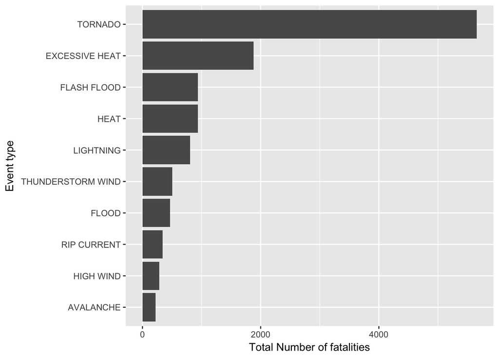

```r
g1<-ggplot(head(topfatality,10),aes(reorder(event,fatality),fatality))
plot1<-g1+geom_bar(stat = "identity")+xlab("Event type")+ylab("Total Number of fatalities")+coord_flip()
plot1
```

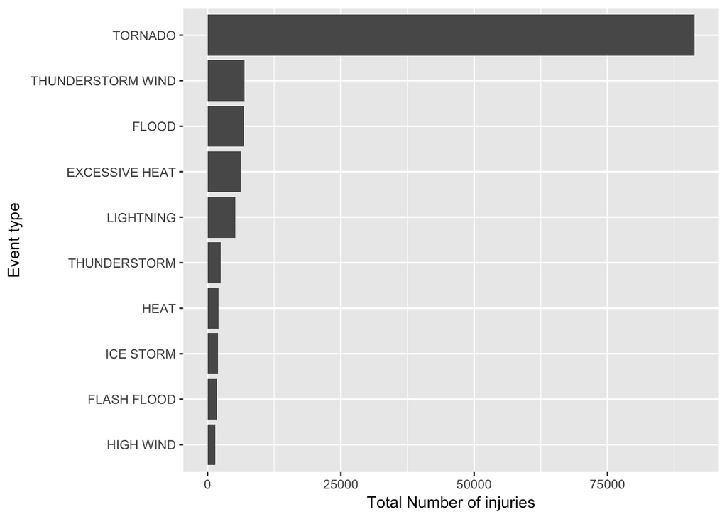

```r
g2<-ggplot(head(topinjury,10),aes(reorder(event,injury),injury))
plot2<-g2+geom_bar(stat = "identity")+xlab("Event type")+ylab("Total Number of injuries")+coord_flip()
plot2
```

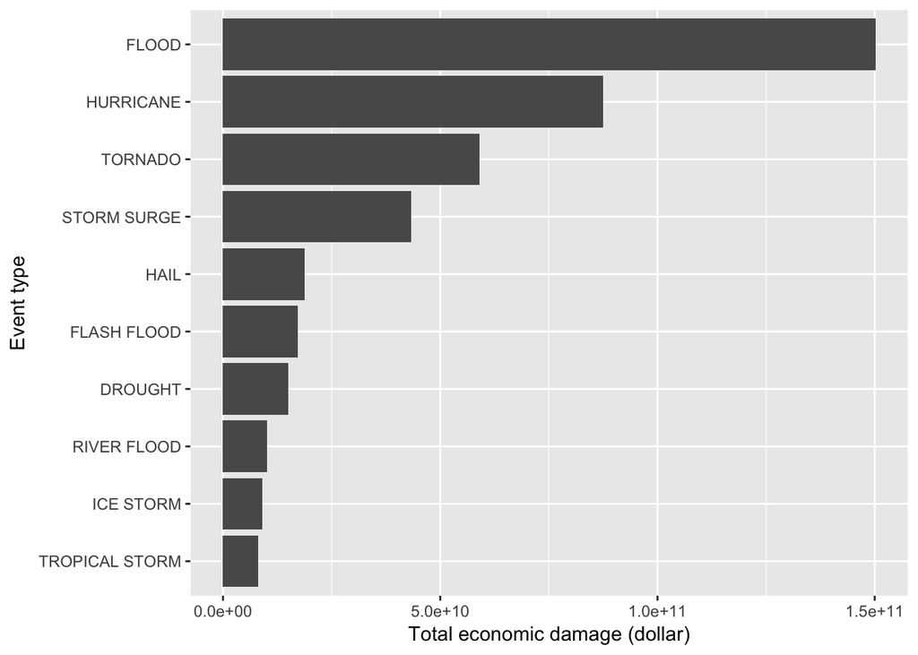

```r
g1<-ggplot(head(topecodmg,10),aes(reorder(event,ecodmg),ecodmg))
plot1<-g1+geom_bar(stat = "identity")+xlab("Event type")+ylab("Total economic damage (dollar)")+coord_flip()
plot1
```